# Sem-UNComa

La Sociología digital: la perspectiva de Deborah Lupton

La sociología en el marco del giro digital

Dr. Agustín Nieto (INHUS-CONICET/UNMdP)

agustin.nieto77@gmail.com | @agusnieto77

07 de septiembre de 2023

[figure not shown]

# ¿Quién es Deborah Lupton?

Deborah Lupton ha contribuido al campo de la sociología digital al analizar cómo la tecnología digital moldea nuestras vidas sociales, culturales y personales. Su trabajo se centra en comprender las interacciones humanas en el entorno digital y cómo estas interacciones están en constante evolución en respuesta a las tecnologías emergentes.

[figure not shown]

## ¿Qué es la sociología digital?

“La sociología digital se refiere a la aplicación de conceptos, teorías y enfoques de investigación sociológicos al análisis de los aspectos sociales de las tecnologías digitales en toda su variedad disponible en la actualidad”

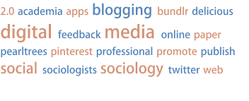

# Debates en la investigación social digital

“Los principales debates giran en torno a cuestiones como la desinformación, el modo en que los discursos violentos y las teorías de la conspiración se propagan e instigan a través de las redes sociales y las aplicaciones de mensajería instantánea y, por último, los intereses de mantener el poder corporativo y aumentar los beneficios que hay detrás de todas estas actividades.”

## La agenda de la sociología digital

1. La construcción de un espacio online para la sociología digital.
2. la creación de un espacio impreso para la sociología digital.
3. La construcción de encuentros cara a cara para la sociología digital.
4. La identificación y difusión de las innovaciones en la práctica sociológica.
5. El trabajo conceptual de dilucidar el lenguaje de múltiples facetas de la sociología digital.
6. La creación de una infraestructura para la sociología pública digital.
7. La elaboración de repertorios metodológicos de sociología digital.

# Sem-UNComa

**Continuará…**

Dr. Agustín Nieto (INHUS-CONICET/UNMdP)

agustin.nieto77@gmail.com | @agusnieto77

07 de septiemnbre de 2023

[figure not shown]